# VaR_Historical_Sim

```python
# Importing libraries for gathering data and visualization
import numpy as np
import pandas as pd
import yfinance as yf
from pandas_datareader import data as pdr
import matplotlib.pyplot as plt
import seaborn as sns

yf.pdr_override() # use yahoo finance for data
```

- The selected stocks are from the Korean stock market (KOSPI, KOSDAQ)
- The theme for the selection focuses on battery suppliers

Investment Portfolio:

| Count | 종목명 | 종목코드 | Listing |
| --- | --- | --- | --- |
| 1 | POSCO홀딩스 | 005490 | 코스피 |
| 2 | 나노신소재 | 121600 | 코스닥 |
| 3 | LG화학 | 051910 | 코스피 |
| 4 | 에코프로비엠 | 247540 | 코스닥 |
| 5 | 천보 | 278280 | 코스닥 |
| 6 | 삼성SDI | 006400 | 코스피 |
| 7 | 코스모화학 | 005420 | 코스피 |
| 8 | 엠플러스 | 259630 | 코스닥 |
| 9 | 에이에프더블류 | 312610 | 코스닥 |
| 10 | 후성 | 093370 | 코스피 |

```python
# Gathering data
tickers = {'005490.KS': 'POSCO홀딩스',
 '121600.KQ': '나노신소재',
 '051910.KS': 'LG화학',
 '247540.KQ': '에코프로비엠',
 '278280.KQ': '천보',
 '006400.KS': '삼성SDI',
 '005420.KS': '코스모화학',
 '259630.KQ': '엠플러스',
 '312610.KQ': '에이에프더블류',
 '093370.KS': '후성'}

stock_data = pdr.DataReader(list(tickers.keys()), start='2020-06-01', end='2023-06-01')
```

```
[*********************100%***********************]  10 of 10 completed
```

```python
# Extract adjusted closing price columns for each stock
stock_prices = stock_data[[('Adj Close', s) for s in tickers.keys()]]
```

```python
stock_prices.columns = stock_prices.columns.droplevel(0)					# Remove multi-index
stock_prices.columns = [tickers[symbol] for symbol in stock_prices.columns] # Rename columns from ticker numbers to company names
stock_prices
```

| Date | POSCO홀딩스 | 나노신소재 | LG화학 | 에코프로비엠 | 천보 | 삼성SDI | 코스모화학 | 엠플러스 | 에이에프더블류 | 후성 |
| --- | --- | --- | --- | --- | --- | --- | --- | --- | --- | --- |
| 2020-06-01 | 159678.796875 | 16748.148438 | 377598.50000 | 29663.023438 | 93605.234375 | 364181.93750 | 7768.067383 | 10474.100586 | 7100.0 | 8100.364258 |
| 2020-06-02 | 165366.015625 | 16349.381836 | 376645.00000 | 29439.056641 | 91509.593750 | 368162.06250 | 7724.328613 | 10474.100586 | 7000.0 | 8359.735352 |
| 2020-06-03 | 177177.828125 | 15900.771484 | 381889.40625 | 28344.113281 | 87118.734375 | 364181.93750 | 7698.084961 | 10052.158203 | 6825.0 | 8269.953125 |
| 2020-06-04 | 177615.312500 | 16698.302734 | 398099.46875 | 29289.746094 | 88116.656250 | 368659.56250 | 7925.528320 | 10052.158203 | 7000.0 | 8429.566406 |
| 2020-06-05 | 175427.937500 | 16449.074219 | 413832.75000 | 29488.828125 | 89813.125000 | 369654.59375 | 7864.293457 | 10027.337891 | 6800.0 | 8659.009766 |
| ... | ... | ... | ... | ... | ... | ... | ... | ... | ... | ... |
| 2023-05-24 | 371000.000000 | 134800.000000 | 720000.00000 | 246000.000000 | 190000.000000 | 714000.00000 | 53000.000000 | 11500.000000 | 4490.0 | 13240.000000 |
| 2023-05-25 | 365000.000000 | 133000.000000 | 712000.00000 | 243500.000000 | 186100.000000 | 700000.00000 | 50200.000000 | 11900.000000 | 4495.0 | 13050.000000 |
| 2023-05-26 | 360500.000000 | 131100.000000 | 706000.00000 | 238000.000000 | 184200.000000 | 693000.00000 | 49700.000000 | 11960.000000 | 4300.0 | 12990.000000 |
| 2023-05-30 | 363000.000000 | 132800.000000 | 702000.00000 | 239000.000000 | 189500.000000 | 718000.00000 | 48550.000000 | 11840.000000 | 4250.0 | 14050.000000 |
| 2023-05-31 | 360000.000000 | 133900.000000 | 693000.00000 | 249000.000000 | 189800.000000 | 718000.00000 | 49450.000000 | 11950.000000 | 4225.0 | 13670.000000 |

741 rows × 10 columns

```python
# Calculate daily returns
stock_returns = stock_prices.pct_change()
stock_returns
```

| Date | POSCO홀딩스 | 나노신소재 | LG화학 | 에코프로비엠 | 천보 | 삼성SDI | 코스모화학 | 엠플러스 | 에이에프더블류 | 후성 |
| --- | --- | --- | --- | --- | --- | --- | --- | --- | --- | --- |
| 2020-06-01 | NaN | NaN | NaN | NaN | NaN | NaN | NaN | NaN | NaN | NaN |
| 2020-06-02 | 0.035617 | -0.023810 | -0.002525 | -0.007550 | -0.022388 | 0.010929 | -0.005631 | 0.000000 | -0.014085 | 0.032020 |
| 2020-06-03 | 0.071428 | -0.027439 | 0.013924 | -0.037194 | -0.047983 | -0.010811 | -0.003398 | -0.040284 | -0.025000 | -0.010740 |
| 2020-06-04 | 0.002469 | 0.050157 | 0.042447 | 0.033363 | 0.011455 | 0.012295 | 0.029545 | 0.000000 | 0.025641 | 0.019300 |
| 2020-06-05 | -0.012315 | -0.014925 | 0.039521 | 0.006797 | 0.019253 | 0.002699 | -0.007726 | -0.002469 | -0.028571 | 0.027219 |
| ... | ... | ... | ... | ... | ... | ... | ... | ... | ... | ... |
| 2023-05-24 | -0.015915 | -0.002959 | 0.001391 | 0.010267 | -0.001052 | 0.005634 | 0.033138 | -0.017933 | -0.013187 | 0.000756 |
| 2023-05-25 | -0.016173 | -0.013353 | -0.011111 | -0.010163 | -0.020526 | -0.019608 | -0.052830 | 0.034783 | 0.001114 | -0.014350 |
| 2023-05-26 | -0.012329 | -0.014286 | -0.008427 | -0.022587 | -0.010210 | -0.010000 | -0.009960 | 0.005042 | -0.043382 | -0.004598 |
| 2023-05-30 | 0.006935 | 0.012967 | -0.005666 | 0.004202 | 0.028773 | 0.036075 | -0.023139 | -0.010033 | -0.011628 | 0.081601 |
| 2023-05-31 | -0.008264 | 0.008283 | -0.012821 | 0.041841 | 0.001583 | 0.000000 | 0.018538 | 0.009291 | -0.005882 | -0.027046 |

741 rows × 10 columns

##### Constraints:

- The portlio will invest in all 10 selected stocks
- The weights for each investment will be determined by Sharpe Ratio

$$Sharpe Ratio = \frac{R_s - R_f}{\sigma_s}$$

Where $R_f = Risk\ Free\ Rate$ and we assume it to be 2% for this experiment

```python
# Calculate risk adjusted mean returns for the first 239 days
import math

rf = .02
sample_returns = stock_returns.iloc[1:239]
sharpe = (sample_returns.mean() * 252 - rf) / (sample_returns.std() * math.sqrt(252)) # Sharpe Ratio
sharpe
```

```
POSCO홀딩스    2.286115
나노신소재       1.095465
LG화학        1.885391
에코프로비엠      1.008613
천보          1.313734
삼성SDI       1.517868
코스모화학       0.654373
엠플러스        0.684578
에이에프더블류     0.759024
후성          0.623870
dtype: float64
```

```python
# Initial investment for the portfolio is 10 billion won
initial_investment = 10_000_000_000

# Allocate the initial investment to each stock according to each stock's sharpe ratio
total = sharpe.sum()
allocation_pct = sharpe / total							   # percent allocation
allocation = (initial_investment * allocation_pct).round() # dollar allocation
allocation
```

```
POSCO홀딩스    1.932631e+09
나노신소재       9.260817e+08
LG화학        1.593868e+09
에코프로비엠      8.526590e+08
천보          1.110602e+09
삼성SDI       1.283172e+09
코스모화학       5.531922e+08
엠플러스        5.787272e+08
에이에프더블류     6.416619e+08
후성          5.274059e+08
dtype: float64
```

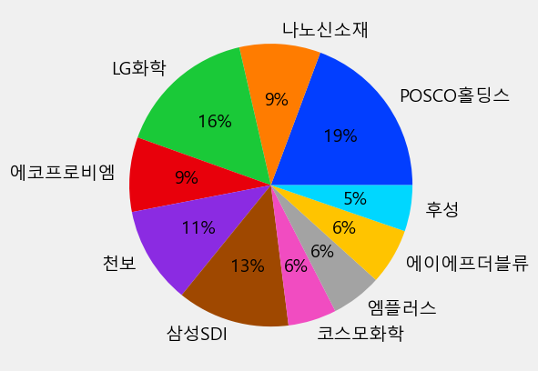

```python
plt.style.use('fivethirtyeight')
np.random.seed(777)
plt.rc('font', family='Malgun Gothic')
plt.rcParams['axes.unicode_minus'] = False

fig, ax = plt.subplots()
ax.pie(allocation, labels=allocation.index, colors = sns.color_palette("bright"), autopct='%.0f%%')
plt.show()
```

# Estimate 1-day VaRs under 95% and 99% confidence levels

### Historical Simulation Approach (HSA)

### 1) Basic Approach

```python
# Separate 500 days of data
test_returns = stock_returns.iloc[241:]
test_returns
```

| Date | POSCO홀딩스 | 나노신소재 | LG화학 | 에코프로비엠 | 천보 | 삼성SDI | 코스모화학 | 엠플러스 | 에이에프더블류 | 후성 |
| --- | --- | --- | --- | --- | --- | --- | --- | --- | --- | --- |
| 2021-05-21 | -0.013699 | -0.005172 | -0.009967 | -0.015882 | -0.002387 | 0.011006 | -0.017621 | 0.000000 | -0.025773 | 0.000000 |
| 2021-05-24 | -0.012500 | -0.001733 | -0.002237 | -0.005764 | -0.008373 | -0.012442 | -0.008969 | -0.056478 | -0.037037 | -0.018000 |
| 2021-05-25 | 0.007032 | -0.006944 | 0.000000 | 0.010435 | 0.007238 | 0.012598 | 0.009050 | -0.014085 | -0.010989 | 0.003055 |
| 2021-05-26 | -0.025140 | -0.006993 | -0.067265 | 0.007458 | 0.000000 | -0.009331 | -0.017937 | 0.017857 | 0.000000 | 0.025381 |
| 2021-05-27 | 0.031519 | -0.010563 | -0.034856 | 0.012528 | -0.003593 | -0.001570 | 0.009132 | 0.014035 | 0.001111 | -0.012871 |
| ... | ... | ... | ... | ... | ... | ... | ... | ... | ... | ... |
| 2023-05-24 | -0.015915 | -0.002959 | 0.001391 | 0.010267 | -0.001052 | 0.005634 | 0.033138 | -0.017933 | -0.013187 | 0.000756 |
| 2023-05-25 | -0.016173 | -0.013353 | -0.011111 | -0.010163 | -0.020526 | -0.019608 | -0.052830 | 0.034783 | 0.001114 | -0.014350 |
| 2023-05-26 | -0.012329 | -0.014286 | -0.008427 | -0.022587 | -0.010210 | -0.010000 | -0.009960 | 0.005042 | -0.043382 | -0.004598 |
| 2023-05-30 | 0.006935 | 0.012967 | -0.005666 | 0.004202 | 0.028773 | 0.036075 | -0.023139 | -0.010033 | -0.011628 | 0.081601 |
| 2023-05-31 | -0.008264 | 0.008283 | -0.012821 | 0.041841 | 0.001583 | 0.000000 | 0.018538 | 0.009291 | -0.005882 | -0.027046 |

500 rows × 10 columns

```python
portfolio_returns = test_returns.dot(allocation)  # Measuring risk, i.e., daily gain or loss of total portfolio for each "scenario"

# Percentile ranked by "descending order"
portfolio_basic = pd.concat([portfolio_returns,(portfolio_returns.rank(pct=True, ascending=False))], axis=1)
portfolio_basic.columns = ['Losses', 'Rank']
portfolio_basic
```

| Date | Losses | Rank |
| --- | --- | --- |
| 2021-05-21 | -7.550546e+07 | 0.682 |
| 2021-05-24 | -1.304126e+08 | 0.802 |
| 2021-05-25 | 3.167642e+07 | 0.462 |
| 2021-05-26 | -1.540892e+08 | 0.832 |
| 2021-05-27 | 7.352831e+06 | 0.524 |
| ... | ... | ... |
| 2023-05-24 | -1.657511e+07 | 0.590 |
| 2023-05-25 | -1.339028e+08 | 0.806 |
| 2023-05-26 | -1.267709e+08 | 0.798 |
| 2023-05-30 | 1.151781e+08 | 0.266 |
| 2023-05-31 | 6.291514e+06 | 0.526 |

500 rows × 2 columns

```python
sorted_basic = portfolio_basic.sort_values('Rank', ascending=False)
```

```python
VaR_95_basic = -int(sorted_basic.iloc[int(.05*len(sorted_basic)-1)]['Losses'])
VaR_99_basic = -int(sorted_basic.iloc[int(.01*len(sorted_basic)-1)]['Losses'])
print(f"1-day VaR (95% confidence level) basic: {VaR_95_basic:,} won")
print(f"1-day VaR (99% confidence level) basic: {VaR_99_basic:,} won")
```

```
1-day VaR (95% confidence level) basic: 311,639,862 won
1-day VaR (99% confidence level) basic: 489,127,583 won
```

### 2) Age-Weighted Approach

$$\frac{\lambda^{n-i}(1-\lambda)}{1-\lambda^n}$$

$\lambda$ = weighting scheme, smaller gives more weight to recent data (where, $\lambda$ < 1)

n = number of data points

i = specific data point (where higher means closer to present)

```python
weight_df = pd.DataFrame(columns = ["Days", "Losses"])
weight_df["Losses"] = portfolio_returns
weight_df['Days'] = range(1,501)						# create i

lmda = .995												# arbitrarily picked lambda parameter
n = weight_df["Days"][-1]
weight_df['Weight'] = ( ( lmda**(n-weight_df["Days"]) * (1-lmda) )/(1-lmda**n)  )
weight_df
```

| Date | Days | Losses | Weight |
| --- | --- | --- | --- |
| 2021-05-21 | 1 | -7.550546e+07 | 0.000446 |
| 2021-05-24 | 2 | -1.304126e+08 | 0.000449 |
| 2021-05-25 | 3 | 3.167642e+07 | 0.000451 |
| 2021-05-26 | 4 | -1.540892e+08 | 0.000453 |
| 2021-05-27 | 5 | 7.352831e+06 | 0.000455 |
| ... | ... | ... | ... |
| 2023-05-24 | 496 | -1.657511e+07 | 0.005336 |
| 2023-05-25 | 497 | -1.339028e+08 | 0.005363 |
| 2023-05-26 | 498 | -1.267709e+08 | 0.005390 |
| 2023-05-30 | 499 | 1.151781e+08 | 0.005417 |
| 2023-05-31 | 500 | 6.291514e+06 | 0.005444 |

500 rows × 3 columns

```python
sorted_weight = weight_df.sort_values("Losses")
sorted_weight
```

| Date | Days | Losses | Weight |
| --- | --- | --- | --- |
| 2022-09-26 | 332 | -5.922471e+08 | 0.002345 |
| 2022-02-24 | 189 | -5.860106e+08 | 0.001145 |
| 2023-04-25 | 477 | -5.711782e+08 | 0.004851 |
| 2022-06-30 | 273 | -5.241805e+08 | 0.001745 |
| 2021-08-17 | 62 | -4.891276e+08 | 0.000606 |
| ... | ... | ... | ... |
| 2021-10-13 | 98 | 4.653051e+08 | 0.000726 |
| 2023-02-16 | 430 | 5.089511e+08 | 0.003833 |
| 2022-10-27 | 353 | 5.275831e+08 | 0.002606 |
| 2023-04-10 | 466 | 5.644004e+08 | 0.004591 |
| 2023-04-03 | 461 | 5.817396e+08 | 0.004477 |

500 rows × 3 columns

```python
sorted_weight["Cumulative"] = sorted_weight['Weight'].cumsum()
sorted_weight
```

| Date | Days | Losses | Weight | Cumulative |
| --- | --- | --- | --- | --- |
| 2022-09-26 | 332 | -5.922471e+08 | 0.002345 | 0.002345 |
| 2022-02-24 | 189 | -5.860106e+08 | 0.001145 | 0.003491 |
| 2023-04-25 | 477 | -5.711782e+08 | 0.004851 | 0.008342 |
| 2022-06-30 | 273 | -5.241805e+08 | 0.001745 | 0.010087 |
| 2021-08-17 | 62 | -4.891276e+08 | 0.000606 | 0.010693 |
| ... | ... | ... | ... | ... |
| 2021-10-13 | 98 | 4.653051e+08 | 0.000726 | 0.984493 |
| 2023-02-16 | 430 | 5.089511e+08 | 0.003833 | 0.988326 |
| 2022-10-27 | 353 | 5.275831e+08 | 0.002606 | 0.990932 |
| 2023-04-10 | 466 | 5.644004e+08 | 0.004591 | 0.995523 |
| 2023-04-03 | 461 | 5.817396e+08 | 0.004477 | 1.000000 |

500 rows × 4 columns

```python
mask_95 = (sorted_weight['Cumulative'] > .05)
mask_99 = (sorted_weight['Cumulative'] > .01)
VaR_95_weight = -int(sorted_weight[mask_95].iloc[0][["Losses"]])
VaR_99_weight = -int(sorted_weight[mask_99].iloc[0][["Losses"]])

print(f"1-day VaR (95% confidence level) weighted: {VaR_95_weight:,} won")
print(f"1-day VaR (99% confidence level) weighted: {VaR_99_weight:,} won")
```

```
1-day VaR (95% confidence level) weighted: 313,829,605 won
1-day VaR (99% confidence level) weighted: 524,180,519 won
```

### 3) Volatility Updating Approach: GARCH(1,1)

$ \sigma^2_n = \gamma V_L + \alpha \mu^2_{n-1} + \beta\sigma^2_{n-1}$

$ \sigma^2_n = \omega + \alpha \mu^2_{n-1} + \beta\sigma^2_{n-1}$

Where $\gamma + \alpha + \beta = 1$ and $\alpha+\beta\ < 1$

For the parameters $\omega, \alpha, \beta$ we estimate them by utilising maximum likelihood method (MLE)

$\sum_{i=1}^{N} [-ln(v_i)-\frac{\mu^2_i}{v_i}]$

Where N denotes the length of the return series

```python
from arch import arch_model
# Estimate GARCH(1,1) parameters for each stock returns
def garch11(arr: list[float]):
	# Function to return garch11 parameters for a given time series array
	model = arch_model(arr, vol='GARCH',p=1, q=1, mean='Constant')
	res = model.fit(disp='off')
	return res
```

```python
# Estimate GARCH(1,1) and store them in dataframe
models = {company:garch11(test_returns[company]) for company in test_returns.columns}
```

[output not shown]

[output cut: 35 more lines]

[output not shown]

- The percentage changes (daily returns) adjusted for differences in volatility (conditional volatility)

$$\Large \frac{{V_{i-1}+(V_i-V_{i-1})\sigma_{n+1}}\div\sigma_i}{V_{i-1}}$$

where n = number of observations (or last day)

```python
vols = pd.DataFrame({company:models[company].conditional_volatility for company in models})
# Replace volatilities with most recent vol divided by each day's vol
vols2 = vols.copy()
for asset in vols2:
    vols2[asset] = vols2[asset].apply(lambda x: vols2[asset][-1]/x)

vol_adj_portfolio = pd.DataFrame(test_returns.values * vols2.values, columns=test_returns.columns, index=test_returns.index)
```

```python
# Convert volatility-adjusted returns to P/L
vol_adjusted_pnl = (vol_adj_portfolio.dot(allocation))
vol_adjusted_pnl
```

```
Date
2021-05-21   -9.661016e+07
2021-05-24   -1.563125e+08
2021-05-25    4.310635e+07
2021-05-26   -1.731271e+08
2021-05-27   -1.833721e+05
                  ...
2023-05-24   -1.694048e+07
2023-05-25   -1.319541e+08
2023-05-26   -1.336053e+08
2023-05-30    1.180146e+08
2023-05-31    6.291514e+06
Length: 500, dtype: float64
```

```python
vol_adj_rank = pd.concat([vol_adjusted_pnl,(vol_adjusted_pnl.rank(pct=True, ascending=False))], axis=1)
vol_adj_rank.columns = ['Losses', 'Rank']

vol_adj_rank = vol_adj_rank.sort_values("Losses")
vol_adj_rank
```

| Date | Losses | Rank |
| --- | --- | --- |
| 2022-02-24 | -5.612070e+08 | 1.000 |
| 2022-09-26 | -5.033059e+08 | 0.998 |
| 2022-06-30 | -4.699138e+08 | 0.996 |
| 2021-08-17 | -4.646063e+08 | 0.994 |
| 2023-04-25 | -4.579637e+08 | 0.992 |
| ... | ... | ... |
| 2022-01-12 | 4.500217e+08 | 0.010 |
| 2021-10-13 | 4.654046e+08 | 0.008 |
| 2022-10-27 | 5.004286e+08 | 0.006 |
| 2023-04-03 | 5.046088e+08 | 0.004 |
| 2023-02-16 | 5.216262e+08 | 0.002 |

500 rows × 2 columns

```python
VaR_95_vol = -int(vol_adj_rank.iloc[int(.05*len(vol_adj_rank)-1)]['Losses'])
VaR_99_vol = -int(vol_adj_rank.iloc[int(.01*len(vol_adj_rank)-1)]['Losses'])
print(f"1-day VaR (95% confidence level) Vol-Adjusted: {VaR_95_vol:,} won")
print(f"1-day VaR (99% confidence level) Vol-Adjusted: {VaR_99_vol:,} won")
```

```
1-day VaR (95% confidence level) Vol-Adjusted: 284,982,679 won
1-day VaR (99% confidence level) Vol-Adjusted: 457,963,652 won
```

### 4) Combined Volatility Updating & Age-Weighted Approach

```python
# Make a dataframe with volatility adjusted P/L (Losses) and apply weight scheme
combined_portfolio = pd.DataFrame({'Losses': vol_adjusted_pnl})
combined_portfolio['Days'] = range(1,501)
n = combined_portfolio['Days'][-1]
lmda = .995
combined_portfolio['Weight'] = ( ( lmda**(n-combined_portfolio["Days"]) * (1-lmda) )/(1-lmda**n)  )
combined_portfolio
```

| Date | Losses | Days | Weight |
| --- | --- | --- | --- |
| 2021-05-21 | -9.661016e+07 | 1 | 0.000446 |
| 2021-05-24 | -1.563125e+08 | 2 | 0.000449 |
| 2021-05-25 | 4.310635e+07 | 3 | 0.000451 |
| 2021-05-26 | -1.731271e+08 | 4 | 0.000453 |
| 2021-05-27 | -1.833721e+05 | 5 | 0.000455 |
| ... | ... | ... | ... |
| 2023-05-24 | -1.694048e+07 | 496 | 0.005336 |
| 2023-05-25 | -1.319541e+08 | 497 | 0.005363 |
| 2023-05-26 | -1.336053e+08 | 498 | 0.005390 |
| 2023-05-30 | 1.180146e+08 | 499 | 0.005417 |
| 2023-05-31 | 6.291514e+06 | 500 | 0.005444 |

500 rows × 3 columns

```python
# Sort by volatility adjusted P/L (Losses)
sorted_combined = combined_portfolio.sort_values('Losses')

# Make a cumulative sum of weight column
sorted_combined['Cumulative'] = sorted_combined['Weight'].cumsum()
sorted_combined
```

| Date | Losses | Days | Weight | Cumulative |
| --- | --- | --- | --- | --- |
| 2022-02-24 | -5.612070e+08 | 189 | 0.001145 | 0.001145 |
| 2022-09-26 | -5.033059e+08 | 332 | 0.002345 | 0.003491 |
| 2022-06-30 | -4.699138e+08 | 273 | 0.001745 | 0.005235 |
| 2021-08-17 | -4.646063e+08 | 62 | 0.000606 | 0.005841 |
| 2023-04-25 | -4.579637e+08 | 477 | 0.004851 | 0.010693 |
| ... | ... | ... | ... | ... |
| 2022-01-12 | 4.500217e+08 | 161 | 0.000995 | 0.988358 |
| 2021-10-13 | 4.654046e+08 | 98 | 0.000726 | 0.989084 |
| 2022-10-27 | 5.004286e+08 | 353 | 0.002606 | 0.991690 |
| 2023-04-03 | 5.046088e+08 | 461 | 0.004477 | 0.996167 |
| 2023-02-16 | 5.216262e+08 | 430 | 0.003833 | 1.000000 |

500 rows × 4 columns

```python
mask_95 = (sorted_combined['Cumulative'] > .05)
mask_99 = (sorted_combined['Cumulative'] > .01)
VaR_95_comb = -int(sorted_combined[mask_95].iloc[0][["Losses"]])
VaR_99_comb = -int(sorted_combined[mask_99].iloc[0][["Losses"]])

print(f"1-day VaR (95% confidence level) combined: {VaR_95_comb:,} won")
print(f"1-day VaR (99% confidence level) combined: {VaR_99_comb:,} won")
```

```
1-day VaR (95% confidence level) combined: 275,703,617 won
1-day VaR (99% confidence level) combined: 457,963,652 won
```

```python
results = [VaR_95_basic, VaR_99_basic, VaR_95_weight, VaR_99_weight, VaR_95_vol, VaR_99_vol, VaR_95_comb, VaR_99_comb]
for i in results:
    print(f"{i:,}")
```

```
311,639,862
489,127,583
313,829,605
524,180,519
284,982,679
457,963,652
275,703,617
457,963,652
```

VaR Results Table:

[output not shown]

### Bootstrap simulation

```python
from tqdm import tqdm
```

```python
def bootstrap_VaR(returns_with_weights, simulation_count, confidence_level):
    results_basic = np.zeros(simulation_count)          # Bootstrap array of VaR to store for basic method
    results_weighted = np.zeros(simulation_count)       # Bootstrap array of VaR to store for age-weighted method
    size = len(returns_with_weights)
    level = 1 - confidence_level

    for i in tqdm(range(simulation_count)):
        sample_choices = returns_with_weights.sample(size, replace=True)      # Generate df with randomly picked samples from original data
        sorted_sample = sample_choices.sort_values("Losses")
        basic_var = sorted_sample['Losses'].iloc[int(np.round( size * (level) - 1 ))]
        sorted_sample['Cumulative'] = sorted_sample['Weight'].cumsum()                      # Cumulative sum of weight column
        weight_var = sorted_sample[sorted_sample['Cumulative'] > level].iloc[0]["Losses"]   # First instance of cumulative sum of weights greater than selected confidence level
        results_basic[i] = -int(basic_var)
        results_weighted[i] = -int(weight_var)

    return pd.DataFrame({"Basic": results_basic, "Weighted": results_weighted})
```

##### Results:

```python
bootstrap_basic_99 = bootstrap_VaR(weight_df, 10000, .99)
bootstrap_basic_95 = bootstrap_VaR(weight_df, 10000, .95)
bootstrap_vol_99 = bootstrap_VaR(combined_portfolio, 10000, .99)
bootstrap_vol_95 = bootstrap_VaR(combined_portfolio, 10000, .95)
```

```python
thousand_separator = lambda x: f"{x:,}"
```

```python
bootstrap_basic_95.quantile([.0275, .975]).T.astype(int).applymap(thousand_separator)
```

|  | 0.0275 | 0.9750 |
| --- | --- | --- |
| Basic | 268,182,912 | 347,027,606 |
| Weighted | 268,182,912 | 348,080,212 |

```python
bootstrap_basic_99.quantile([.0275, .975]).T.astype(int).applymap(thousand_separator)
```

|  | 0.0275 | 0.9750 |
| --- | --- | --- |
| Basic | 376,407,365 | 586,010,562 |
| Weighted | 365,550,947 | 571,178,222 |

```python
bootstrap_vol_95.quantile([.0275, .975]).T.astype(int).applymap(thousand_separator)
```

|  | 0.0275 | 0.9750 |
| --- | --- | --- |
| Basic | 244,058,724 | 330,863,830 |
| Weighted | 237,598,494 | 330,863,830 |

```python
bootstrap_vol_99.quantile([.0275, .975]).T.astype(int).applymap(thousand_separator)
```

|  | 0.0275 | 0.9750 |
| --- | --- | --- |
| Basic | 351,426,445 | 503,305,940 |
| Weighted | 341,319,857 | 469,913,799 |

VaR Results Table:

[output not shown]

Bootstrap 95% Confidence Interval Results Table:

| Method | 95% VaR Lower | 95% VaR Upper | 99% VaR Lower | 99% VaR Upper |
| --- | --- | --- | --- | --- |
| Basic | 268,182,912 | 347,027,606 | 376,407,365 | 586,010,562 |
| Weighted | 268,182,912 | 348,080,212 | 365,550,947 | 571,178,222 |
| Vol-Adj | 244,058,724 | 330,863,830 | 351,426,445 | 503,305,940 |
| Combined | 237,598,494 | 330,863,830 | 341,319,857 | 469,913,799 |

Each of the Value at Risk calculated falls within the 95% confidence interval of the bootstrapped results as can be seen from the tables